# Forecasting probabilístico con machine learning

**Joaquín Amat Rodrigo, Javier Escobar Ortiz**

*Abril, 2022 (última actualización Noviembre 2024)*

Más sobre forecasting en: [**cienciadedatos.net**](https://cienciadedatos.net)

- [Forecasting series temporales con machine learning](https://www.cienciadedatos.net/documentos/py27-forecasting-series-temporales-python-scikitlearn.html)
- [Modelos ARIMA y SARIMAX](https://cienciadedatos.net/documentos/py51-modelos-arima-sarimax-python.html)
- [Forecasting series temporales con gradient boosting: XGBoost, LightGBM y CatBoost](https://www.cienciadedatos.net/documentos/py39-forecasting-series-temporales-con-skforecast-xgboost-lightgbm-catboost.html)
- [Global Forecasting: Multi-series forecasting](https://www.cienciadedatos.net/documentos/py44-multi-series-forecasting-skforecast-espa%C3%B1ol.html)
- [Forecasting de la demanda eléctrica con machine learning](https://www.cienciadedatos.net/documentos/py29-forecasting-demanda-energia-electrica-python.html)
- [Forecasting con deep learning](https://cienciadedatos.net/documentos/py54-forecasting-con-deep-learning)
- [Forecasting de visitas a página web con machine learning](https://www.cienciadedatos.net/documentos/py37-forecasting-visitas-web-machine-learning.html)
- [Forecasting del precio de Bitcoin](https://www.cienciadedatos.net/documentos/py41-forecasting-criptomoneda-bitcoin-machine-learning-python.html)
- [Forecasting probabilístico](https://cienciadedatos.net/documentos/py42-forecasting-probabilistico.html)
- [Forecasting de demanda intermitente](https://www.cienciadedatos.net/documentos/py48-forecasting-demanda-intermitente.html)
- [Reducir el impacto del Covid en modelos de forecasting](https://www.cienciadedatos.net/documentos/py45-weighted-time-series-forecasting-es.html)
- [Modelar series temporales con tendencia utilizando modelos de árboles](https://www.cienciadedatos.net/documentos/py49-modelar-tendencia-en-series-temporales-modelos-de-arboles.html)

[figure not shown]

## Introducción

Al tratar de anticipar valores futuros de una serie temporal, la mayoría de los modelos de *forecasting* intentan predecir cuál será el valor más probable, esto se llama *point-forecasting*. Aunque conocer de antemano el valor esperado de una serie temporal es útil en casi todos los casos de negocio, este tipo de predicción no proporciona información sobre la confianza del modelo ni sobre la incertidumbre de sus predicciones.

El *forecasting* probabilístico, a diferencia del *point-forecasting*, es una familia de técnicas que permiten predecir la distribución esperada de la variable respuesta en lugar de un único valor puntual. Este tipo de *forecasting* proporciona información muy valiosa ya que permite crear intervalos de predicción, es decir, el rango de valores donde es más probable que pueda estar el valor real. Más formalmente, un intervalo de predicción define el intervalo dentro del cual se espera encontrar el verdadero valor de la variable respuesta con una determinada probabilidad.

Existen [múltiples formas de estimar intervalos de predicción en modelos de *forecasting*](https://otexts.com/fpp3/prediction-intervals.html), la mayoría de las cuales requieren que los residuos (errores) del modelo sigan una distribución normal. Cuando no se puede asumir esta propiedad, dos alternativas comúnmente utilizadas son el *bootstrapping* y la regresión cuantílica. Para ilustrar cómo la librería [skforecast](https://skforecast.org/) permite estimar intervalos de predicción en modelos de *forecasting multi-step* se muestran dos ejemplo:

- Intervalos de predicción basados en *bootstrapping* para un modelo de tipo [recursive-multi-step forecaster](https://skforecast.org/latest/user_guides/autoregresive-forecaster.html).
- Intervalos de predicción basados en regresión cuantílica para un modelo de tipo [direct-multi-step forecaster](https://skforecast.org/latest/user_guides/direct-multi-step-forecasting.html).

**⚠ Warning**

Tal y como describe Rob J Hyndman en su [blog](https://robjhyndman.com/hyndsight/narrow-pi/), en los casos reales, casi todos los intervalos de predicción resultan ser demasiado estrechos. Por ejemplo, intervalos teóricos del 95% solo suelen conseguir una cobertura real de entre el 71% y el 87%. Este fenómeno surge debido a que estos intervalos no contemplan todas las fuentes de incertidumbre que, en el caso de modelos de *forecasting*, suelen ser de 4 tipos:

- El término de error aleatorio
- Las estimación de parámetros
- La elección del modelo
- El proceso de predicción de valores futuros

Cuando se calculan intervalos de predicción para modelos de series temporales, generalmente solo se tiene en cuenta el primero de ellos. Por lo tanto, es recomendable utilizar datos de test para validar la cobertura real del intervalo y no confiar únicamente en la esperada.

**✎ Note**

*Conformal prediction* es un método relativamente nuevo que permite estimar la incertidumbre aociada a las predicciones de modelos de machine learning. Este método está en la hoja de ruta de skforecast, pero aún no está disponible.

## Intervalos de predicción utilizando bootstrapping de los residuos

El error en la predicción del siguiente valor de una serie (*one-step-ahead forecast*) se define como $e_t = y_t - \hat{y}_{t|t-1}$. Asumiendo que los errores futuros serán similares a los errores pasados, es posible simular diferentes predicciones tomando muestras de los errores vistos previamente en el pasado (es decir, los residuos) y agregándolos a las predicciones.

[figure not shown]

Al hacer esto repetidamente, se crea una colección de predicciones ligeramente diferentes (posibles caminos futuros), que representan la varianza esperada en el proceso de *forecasting*.

[figure not shown]

Finalmente, los intervalos de predicción se crean calculando los percentiles $\alpha/2$ y $1−\alpha/2$ de los datos simulados en cada horizonte de predicción.

[figure not shown]

La principal ventaja de esta estrategia es que solo requiere de un único modelo para estimar cualquier intervalo. El inconveniente es la necesidad de ejecutar cientos o miles de iteraciones de *bootstrapping* lo cual resulta muy costoso desde el punto de vista computacional y no siempre es posible.

### Librerías

```python
# Preprocesado de datos
# ==============================================================================
import numpy as np
import pandas as pd
from skforecast.datasets import fetch_dataset

# Plots
# ==============================================================================
import matplotlib.pyplot as plt
from statsmodels.graphics.tsaplots import plot_acf
from statsmodels.graphics.tsaplots import plot_pacf
import plotly.graph_objects as go
import plotly.io as pio
import plotly.offline as poff
pio.templates.default = "seaborn"
pio.renderers.default = 'notebook'
poff.init_notebook_mode(connected=True)
plt.style.use('seaborn-v0_8-darkgrid')
from skforecast.plot import plot_residuals
from skforecast.plot import plot_prediction_distribution
from pprint import pprint

# Modelado y Forecasting
# ==============================================================================
import skforecast
import sklearn
import lightgbm
from lightgbm import LGBMRegressor
from sklearn.preprocessing import OneHotEncoder
from sklearn.compose import ColumnTransformer
from skforecast.recursive import ForecasterRecursive
from skforecast.direct import ForecasterDirect
from skforecast.model_selection import TimeSeriesFold
from skforecast.model_selection import bayesian_search_forecaster
from skforecast.model_selection import backtesting_forecaster
from sklearn.metrics import mean_pinball_loss
from scipy.stats import norm

# Configuración
# ==============================================================================
import warnings
warnings.filterwarnings('once')

color = '\033[1m\033[38;5;208m'
print(f"{color}Versión skforecast: {skforecast.__version__}")
print(f"{color}Versión scikit-learn: {sklearn.__version__}")
print(f"{color}Version lightgbm: {lightgbm.__version__}")
print(f"{color}Versión pandas: {pd.__version__}")
print(f"{color}Versión numpy: {np.__version__}")
```

```
Versión skforecast: 0.14.0
Versión scikit-learn: 1.5.2
Version lightgbm: 4.4.0
Versión pandas: 2.2.3
Versión numpy: 2.0.2
```

### Datos

```python
# Descarga de datos
# ==============================================================================
data = fetch_dataset(name='bike_sharing_extended_features')
data.head(2)
```

```
bike_sharing_extended_features
------------------------------
Hourly usage of the bike share system in the city of Washington D.C. during the
years 2011 and 2012. In addition to the number of users per hour, the dataset
was enriched by introducing supplementary features. Addition includes calendar-
based variables (day of the week, hour of the day, month, etc.), indicators for
sunlight, incorporation of rolling temperature averages, and the creation of
polynomial features generated from variable pairs. All cyclic variables are
encoded using sine and cosine functions to ensure accurate representation.
Fanaee-T,Hadi. (2013). Bike Sharing Dataset. UCI Machine Learning Repository.
https://doi.org/10.24432/C5W894.
Shape of the dataset: (17352, 90)
```

| date_time | users | weather | month_sin | month_cos | week_of_year_sin | week_of_year_cos | week_day_sin | week_day_cos | hour_day_sin | hour_day_cos | ... | temp_roll_mean_1_day | temp_roll_mean_7_day | temp_roll_max_1_day | temp_roll_min_1_day | temp_roll_max_7_day | temp_roll_min_7_day | holiday_previous_day | holiday_next_day | temp | holiday |
| --- | --- | --- | --- | --- | --- | --- | --- | --- | --- | --- | --- | --- | --- | --- | --- | --- | --- | --- | --- | --- | --- |
| 2011-01-08 00:00:00 | 25.0 | mist | 0.5 | 0.866025 | 0.120537 | 0.992709 | -0.781832 | 0.62349 | 0.258819 | 0.965926 | ... | 8.063334 | 10.127976 | 9.02 | 6.56 | 18.86 | 4.92 | 0.0 | 0.0 | 7.38 | 0.0 |
| 2011-01-08 01:00:00 | 16.0 | mist | 0.5 | 0.866025 | 0.120537 | 0.992709 | -0.781832 | 0.62349 | 0.500000 | 0.866025 | ... | 8.029166 | 10.113334 | 9.02 | 6.56 | 18.86 | 4.92 | 0.0 | 0.0 | 7.38 | 0.0 |

2 rows × 90 columns

```python
# One hot encoding de las variables categóricas
# ==============================================================================
encoder = ColumnTransformer(
              [('one_hot_encoder', OneHotEncoder(sparse_output=False), ['weather'])],
              remainder='passthrough',
              verbose_feature_names_out=False
          ).set_output(transform="pandas")
data = encoder.fit_transform(data)
```

```python
# Selección de las variables exógenas
# ==============================================================================
exog_features = [
    'weather_clear', 'weather_mist', 'weather_rain', 'month_sin', 'month_cos',
    'week_of_year_sin', 'week_of_year_cos', 'week_day_sin', 'week_day_cos',
    'hour_day_sin', 'hour_day_cos', 'sunrise_hour_sin', 'sunrise_hour_cos',
    'sunset_hour_sin', 'sunset_hour_cos', 'temp'
]
data = data[['users'] + exog_features]
```

Para facilitar el entrenamiento de los modelos, la búsqueda de hiperparámetros óptimos y la evaluación de su capacidad predictiva, los datos se dividen en tres conjuntos separados: entrenamiento, validación y prueba.

```python
# Partición de datos en entrenamiento-validación-test
# ==============================================================================
data = data.loc['2011-05-30 23:59:00':, :]
end_train = '2012-08-30 23:59:00'
end_validation = '2012-11-15 23:59:00'
data_train = data.loc[: end_train, :]
data_val   = data.loc[end_train:end_validation, :]
data_test  = data.loc[end_validation:, :]

print(f"Dates train      : {data_train.index.min()} --- {data_train.index.max()}  (n={len(data_train)})")
print(f"Dates validacion : {data_val.index.min()} --- {data_val.index.max()}  (n={len(data_val)})")
print(f"Dates test       : {data_test.index.min()} --- {data_test.index.max()}  (n={len(data_test)})")
```

```
Dates train      : 2011-05-31 00:00:00 --- 2012-08-30 23:00:00  (n=10992)
Dates validacion : 2012-08-31 00:00:00 --- 2012-11-15 23:00:00  (n=1848)
Dates test       : 2012-11-16 00:00:00 --- 2012-12-30 23:00:00  (n=1080)
```

### Exploración gráfica

La exploración gráfica de series temporales puede ser una forma eficaz de identificar tendencias, patrones y variaciones estacionales. Esto, a su vez, ayuda a orientar la selección del modelo de forecasting más adecuado.

```python
# Gráfico de la serie temporal
# ==============================================================================
fig = go.Figure()
fig.add_trace(go.Scatter(x=data_train.index, y=data_train['users'], mode='lines', name='Train'))
fig.add_trace(go.Scatter(x=data_val.index, y=data_val['users'], mode='lines', name='Validation'))
fig.add_trace(go.Scatter(x=data_test.index, y=data_test['users'], mode='lines', name='Test'))
fig.update_layout(
    title  = 'Número de usuarios',
    xaxis_title="Fecha",
    yaxis_title="Usuarios",
    width=750,
    height=350,
    margin=dict(l=20, r=20, t=35, b=20),
    legend=dict(
        orientation="h",
        yanchor="top",
        y=1,
        xanchor="left",
        x=0.001
    )
)
fig.show()
```

[interactive chart not shown]

Los gráficos de autocorrelación muestran la correlación entre una serie temporal y sus valores pasados. Son una herramienta útil para identificar el orden de un modelo autorregresivo, es decir, los valores pasados (lags) que se deben incluir en el modelo.

La función de autocorrelación (ACF) mide la correlación entre una serie temporal y sus valores pasados. La función de autocorrelación parcial (PACF) mide la correlación entre una serie temporal y sus valores pasados, pero solo después de eliminar las variaciones explicadas por los valores pasados intermedios.

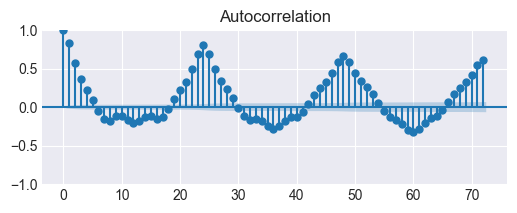

```python
# Gráfico de autocorrelación
# ==============================================================================
fig, ax = plt.subplots(figsize=(6, 2))
plot_acf(data.users, ax=ax, lags=24 * 3)
plt.show()
```

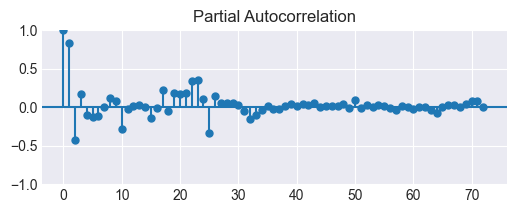

```python
# Gráfico autocorrelación parcial
# ==============================================================================
fig, ax = plt.subplots(figsize=(6, 2))
plot_pacf(data.users, ax=ax, lags=24 * 3)
plt.show()
```

Los resultados del estudio de autocorrelación indican una correlación significativa entre el número de usuarios en las horas anteriores, así como en los días previos. Esto significa que conocer del número de usuarios durante periodos específicos del pasado proporciona información útil para predecir el número de usuarios en el futuro.

### Residuos *in-sample*

Se entrena un [*recursive-multi-step forecaster*](https://skforecast.org/latest/user_guides/autoregresive-forecaster.html) y se [optimiza sus hiperparámetros](https://skforecast.org/latest/user_guides/hyperparameter-tuning-and-lags-selection). Luego, se estiman los intervalos de predicción utilizando bootstrapping.

```python
# Create forecaster and hyperparameters search
# ==============================================================================
# Forecaster
forecaster = ForecasterRecursive(
                regressor = LGBMRegressor(random_state=15926, verbose=-1),
                lags = 7
            )

# Lags used as predictors
lags_grid = [24, 48, (1, 2, 3, 23, 24, 25, 47, 48, 49, 71, 72, 73, 364*24, 365*24)]

# Particiones
cv = TimeSeriesFold(
        steps              = 24,
        initial_train_size = len(data[:end_train]),
        refit              = False,
     )

# Regressor hyperparameters search space
def search_space(trial):
    search_space  = {
        'lags'            : trial.suggest_categorical('lags', lags_grid),
        'n_estimators'    : trial.suggest_int('n_estimators', 200, 800, step=100),
        'max_depth'       : trial.suggest_int('max_depth', 3, 8, step=1),
        'min_data_in_leaf': trial.suggest_int('min_data_in_leaf', 25, 500),
        'learning_rate'   : trial.suggest_float('learning_rate', 0.01, 0.5),
        'feature_fraction': trial.suggest_float('feature_fraction', 0.5, 0.8, step=0.1),
        'max_bin'         : trial.suggest_int('max_bin', 50, 100, step=25),
        'reg_alpha'       : trial.suggest_float('reg_alpha', 0, 1, step=0.1),
        'reg_lambda'      : trial.suggest_float('reg_lambda', 0, 1, step=0.1)
    }
    return search_space

results_search, frozen_trial = bayesian_search_forecaster(
                                   forecaster    = forecaster,
                                   y             = data.loc[:end_validation, 'users'],
                                   exog          = data.loc[:end_validation, exog_features],
                                   cv            = cv,
                                   metric        = 'mean_absolute_error',
                                   search_space  = search_space,
                                   n_trials      = 20,
                                   random_state  = 123,
                                   return_best   = True,
                                   n_jobs        = 'auto',
                                   verbose       = False,
                                   show_progress = True
                               )
best_params = results_search['params'].iloc[0]
best_lags   = results_search['lags'].iloc[0]
```

```
`Forecaster` refitted using the best-found lags and parameters, and the whole data set:
  Lags: [   1    2    3   23   24   25   47   48   49   71   72   73 8736 8760]
  Parameters: {'n_estimators': 300, 'max_depth': 5, 'min_data_in_leaf': 25, 'learning_rate': 0.10794173876361574, 'feature_fraction': 0.6, 'max_bin': 100, 'reg_alpha': 1.0, 'reg_lambda': 1.0}
  Backtesting metric: 55.26098214742841
```

Una vez encontrados los mejores hiperparámetros, se utiliza la función `backtesting_forecaster()` para generar los intervalos de predicción de todo el conjunto de test.

- El argumento `interval` se emplea para especificar la probabilidad de cobertura deseada de los intervalos de predicción. En este caso, `interval` se establece en `[10, 90]`, lo que significa que los intervalos de predicción se calculan para los percentiles 10 y 90, lo que da como resultado una cobertura teórica del 80%.
- El argumento `n_boot` se utiliza para especificar el número de muestras *bootstrap* que se utilizarán para estimar los intervalos de predicción. Cuanto mayor sea el número de muestras, más precisos serán los intervalos de predicción, pero mayor el tiempo necesario.

Por defecto, los intervalos se calculan utilizando los residuos *in-sample* (residuos del conjunto de entrenamiento). Esto puede dar lugar a intervalos demasiado estrechos (demasiado optimistas).

```python
# Backtesting con intervalos en los datos de test usando residuos in-sample
# ==============================================================================
cv = TimeSeriesFold(
        steps              = 24,
        initial_train_size = len(data.loc[:end_validation]),
        refit              = False,
    )
metric, predictions = backtesting_forecaster(
                          forecaster              = forecaster,
                          y                       = data['users'],
                          exog                    = data[exog_features],
                          cv                      = cv,
                          metric                  = 'mean_absolute_error',
                          interval                = [10, 90],
                          n_boot                  = 250,
                          use_in_sample_residuals = True,
                          use_binned_residuals    = False,
                          n_jobs                  = 'auto',
                          verbose                 = False,
                          show_progress           = True
                      )
display(metric)
predictions.head(5)
```

|  | mean_absolute_error |
| --- | --- |
| 0 | 50.462723 |

|  | pred | lower_bound | upper_bound |
| --- | --- | --- | --- |
| 2012-11-16 00:00:00 | 75.957987 | 52.697966 | 100.885160 |
| 2012-11-16 01:00:00 | 22.895924 | 0.953096 | 56.633349 |
| 2012-11-16 02:00:00 | 11.105227 | -12.096016 | 41.032015 |
| 2012-11-16 03:00:00 | 7.465197 | -19.899672 | 34.476395 |
| 2012-11-16 04:00:00 | 6.216360 | -15.973349 | 39.723453 |

```python
# Function to plot predicted intervals
# ======================================================================================
def plot_predicted_intervals(
    predictions: pd.DataFrame,
    y_true: pd.DataFrame,
    target_variable: str,
    initial_x_zoom: list=None,
    title: str=None,
    xaxis_title: str=None,
    yaxis_title: str=None,
):
    """
    Plot predicted intervals vs real values

    Parameters
    ----------
    predictions : pandas DataFrame
        Predicted values and intervals.
    y_true : pandas DataFrame
        Real values of target variable.
    target_variable : str
        Name of target variable.
    initial_x_zoom : list, default `None`
        Initial zoom of x-axis, by default None.
    title : str, default `None`
        Title of the plot, by default None.
    xaxis_title : str, default `None`
        Title of x-axis, by default None.
    yaxis_title : str, default `None`
        Title of y-axis, by default None.

    """

    fig = go.Figure([
        go.Scatter(name='Prediction', x=predictions.index, y=predictions['pred'], mode='lines'),
        go.Scatter(name='Real value', x=y_true.index, y=y_true[target_variable], mode='lines'),
        go.Scatter(
            name='Upper Bound', x=predictions.index, y=predictions['upper_bound'],
            mode='lines', marker=dict(color="#444"), line=dict(width=0), showlegend=False
        ),
        go.Scatter(
            name='Lower Bound', x=predictions.index, y=predictions['lower_bound'],
            marker=dict(color="#444"), line=dict(width=0), mode='lines',
            fillcolor='rgba(68, 68, 68, 0.3)', fill='tonexty', showlegend=False
        )
    ])
    fig.update_layout(
        title=title,
        xaxis_title=xaxis_title,
        yaxis_title=yaxis_title,
        width=750,
        height=350,
        margin=dict(l=20, r=20, t=35, b=20),
        hovermode="x",
        xaxis=dict(range=initial_x_zoom),
        legend=dict(orientation="h", yanchor="top", y=1.1, xanchor="left", x=0.001)
    )
    fig.show()


def empirical_coverage(y, lower_bound, upper_bound):
    """
    Calculate coverage of a given interval
    """
    return np.mean(np.logical_and(y >= lower_bound, y <= upper_bound))
```

```python
# Gráfico intervalos
# ==============================================================================
plot_predicted_intervals(
    predictions     = predictions,
    y_true          = data_test,
    target_variable = "users",
    initial_x_zoom  = ['2012-12-01', '2012-12-25'],
    title           = "Valor real vs predicciones en el conjunto de test",
    xaxis_title     = "Date time",
    yaxis_title     = "users",
)

# Cobertura del intervalo en los datos de test
# ==============================================================================
coverage = empirical_coverage(
                y           = data.loc[end_validation:, 'users'],
                lower_bound = predictions["lower_bound"],
                upper_bound = predictions["upper_bound"]
           )
print(f"Cobertura del intervalo: {round(100 * coverage, 2)} %")

# Area del intervalo
# ==============================================================================
area = (predictions["upper_bound"] - predictions["lower_bound"]).sum()
print(f"Area del intervalo: {round(area, 2)}")
```

[interactive chart not shown]

```
Cobertura del intervalo: 58.15 %
Area del intervalo: 82767.54
```

Los intervalos de predicción presentan un exceso de confianza, ya que tienden a ser demasiado estrechos, lo que da lugar a una cobertura real inferior a la cobertura teóritca (80%). Esto se debe a la tendencia de los residuos de entrenamiento (*in-sample*) a sobrestimar la capacidad de predicción del modelo.

### Residuos Out-sample (no condicionados a los valores predichos)

El método `set_out_sample_residuals()` se utiliza para almacenar residuos fuera de muestra (*out-sample*) calculados con un conjunto de validación a través de *backtesting*. Una vez añadidos los nuevos residuos al foreacster, se tiene que indicar `use_in_sample_residuals` a `False` para que el forecaster los utilice.

```python
# Backtesting con datos de validación para obtener residuos out-sample
# ==============================================================================
cv = TimeSeriesFold(
        steps              = 24,
        initial_train_size = len(data.loc[:end_train]),
        refit              = False,
    )
_, predictions_val = backtesting_forecaster(
                         forecaster    = forecaster,
                         y             = data.loc[:end_validation, 'users'],
                         exog          = data.loc[:end_validation, exog_features],
                         cv            = cv,
                         metric        = 'mean_absolute_error',
                         n_jobs        = 'auto',
                         verbose       = False,
                         show_progress = True
                     )
```

```
positivo    1029
negarivo     819
Name: count, dtype: int64
```

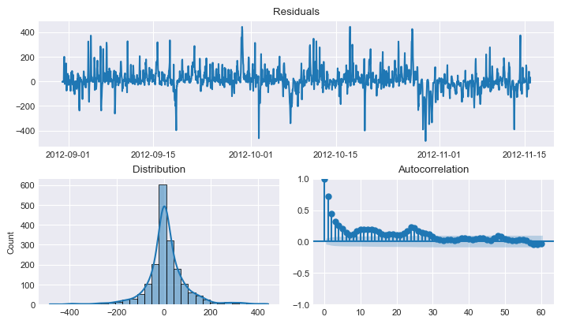

```python
# Distribución residuos out-sample
# ==============================================================================
residuals = data.loc[predictions_val.index, 'users'] - predictions_val['pred']
print(pd.Series(np.where(residuals < 0, 'negarivo', 'positivo')).value_counts())
plt.rcParams.update({'font.size': 8})
_ = plot_residuals(residuals=residuals, figsize=(7, 4))
```

```python
# Almacenar residuos out-sample en el forecaster
# ==============================================================================
forecaster.set_out_sample_residuals(
    y_true = data.loc[predictions_val.index, 'users'],
    y_pred = predictions_val['pred']
)
```

```python
# Backtesting con intervalos en los datos de test usando residuos out-sample
# ==============================================================================
cv = TimeSeriesFold(
        steps              = 24,
        initial_train_size = len(data.loc[:end_validation]),
        refit              = False,
    )
metric, predictions = backtesting_forecaster(
                          forecaster              = forecaster,
                          y                       = data['users'],
                          exog                    = data[exog_features],
                          cv                      = cv,
                          metric                  = 'mean_absolute_error',
                          interval                = [10, 90],
                          n_boot                  = 250,
                          use_in_sample_residuals = False, # Usar residuos out-sample
                          use_binned_residuals    = False,
                          n_jobs                  = 'auto',
                          verbose                 = False,
                          show_progress           = True
                      )
predictions.head(5)
```

|  | pred | lower_bound | upper_bound |
| --- | --- | --- | --- |
| 2012-11-16 00:00:00 | 75.957987 | 3.867451 | 179.864239 |
| 2012-11-16 01:00:00 | 22.895924 | -17.751696 | 175.045007 |
| 2012-11-16 02:00:00 | 11.105227 | -40.826370 | 168.447203 |
| 2012-11-16 03:00:00 | 7.465197 | -28.237689 | 193.401750 |
| 2012-11-16 04:00:00 | 6.216360 | -40.160433 | 184.578289 |

```python
# Gráfico intervalos
# ==============================================================================
plot_predicted_intervals(
    predictions     = predictions,
    y_true          = data_test,
    target_variable = "users",
    initial_x_zoom  = ['2012-12-01', '2012-12-25'],
    title           = "Valor real vs predicciones en el conjunto de test",
    xaxis_title     = "Date time",
    yaxis_title     = "users",
)

# Cobertura del intervalo en los datos de test
# ==============================================================================
coverage = empirical_coverage(
                y           = data.loc[end_validation:, 'users'],
                lower_bound = predictions["lower_bound"],
                upper_bound = predictions["upper_bound"]
            )
print(f"Cobertura del intervalo: {round(100*coverage, 2)} %")

# Area del intervalo
# ==============================================================================
area = (predictions["upper_bound"] - predictions["lower_bound"]).sum()
print(f"Area del intervalo: {round(area, 2)}")
```

[interactive chart not shown]

```
Cobertura del intervalo: 83.43 %
Area del intervalo: 255879.67
```

Los intervalos de predicción obtenidos utilizando los residuos *out-sample* son considerablemente más amplios que los basados en los residuos *in-sample*, lo que da como resultado una cobertura empírica más cercana a la cobertura nominal. Sin embargo, al examinar el gráfico, es fácil ver que los intervalos son especialmente amplios cuando los valores predichos son bajos, lo que indica que el modelo no es capaz de localizar correctamente la incertidumbre de sus predicciones.

### Residuos Out-sample (condicionados a los valores predichos)

El proceso de *bootstrapping* asume que los residuos se distribuyen de forma independiente por lo que pueden utilizarse sin tener en cuenta del valor predicho. En realidad, esto rara vez es cierto; en la mayoría de los casos, la magnitud de los residuos está correlacionado con la magnitud del valor predicho. En este caso, por ejemplo, difícilmente cabría esperar que el error fuera el mismo cuando el número previsto de usuarios es cercano a cero que cuando es de varios cientos.

Para tener en cuenta esta dependencia, skforecast permite distribuir los residuos en *K* intervalos, en los que cada intervalo está asociado a un rango de valores predichos. Con esta estrategia, el proceso de *bootstrapping* muestrea los residuos de diferentes intervalos en función del valor predicho, lo que puede mejorar la cobertura del intervalo y ajustar su anchura cuando sea necesario, permitiendo que el modelo distribuya mejor la incertidumbre de sus predicciones.

Para que el forecaster pueda agrupar los residuos *out-sample*, los valores predichos se pasan al método `set_out_sample_residuals()` junto con los residuos. Internamente, skforecast utiliza un `sklearn.preprocessing.KBinsDiscretizer` con los parámetros: `n_bins=15`, `encode=ordinal`, `strategy=quantile`, `subsample=10000`, `random_state=789654`, `dtype=np.float64`. El proceso de binning puede ajustarse utilizando el argumento `binner_kwargs` del objeto forecaster.

```python
# Crear forecaster
# ==============================================================================
forecaster = ForecasterRecursive(
                regressor     = LGBMRegressor(random_state=15926, verbose=-1, **best_params),
                lags          = best_lags,
                binner_kwargs = {'n_bins': 15}
            )

forecaster.fit(
    y     = data.loc[:end_validation, 'users'],
    exog  = data.loc[:end_validation, exog_features]
)
```

Durante el proceso de entrenamiento, el forecaster utiliza las predicciones *in sample* para definir los intervalos en los que se almacenan los residuos, en función del valor prediccho con el que están relacionados. Aunque no se utilizan en este ejemplo, los residuos *in-sample* también se dividen en intervalos y se almacenan en el atributo `in_sample_residuals_by_bin_`.

```python
# Intervalos de los bins
# ==============================================================================
pprint(forecaster.binner_intervals_)
```

```
{0.0: (-1.741708189819649, 10.317040266602518),
 1.0: (10.317040266602518, 23.397712684935296),
 2.0: (23.397712684935296, 42.81143589390928),
 3.0: (42.81143589390928, 93.70601153260277),
 4.0: (93.70601153260277, 146.00472540188062),
 5.0: (146.00472540188062, 185.98114181351224),
 6.0: (185.98114181351224, 227.94516357708295),
 7.0: (227.94516357708295, 263.17131420814536),
 8.0: (263.17131420814536, 298.7107366143719),
 9.0: (298.7107366143719, 339.1431337029709),
 10.0: (339.1431337029709, 399.04627830804475),
 11.0: (399.04627830804475, 472.88850088361374),
 12.0: (472.88850088361374, 553.7082345948482),
 13.0: (553.7082345948482, 682.5049823044178),
 14.0: (682.5049823044178, 994.5807380527069)}
```

A continuación, los residuos *out-sample* se almacenan en el forecaster. Para evitar un uso excesivo de memoria, se almacena un máximo de *10000//n_bins* residuos por partición (*bin*).

```python
# Almacenar residuos out-sample en el forecaster
# ==============================================================================
forecaster.set_out_sample_residuals(
    y_true = data.loc[predictions_val.index, 'users'],
    y_pred = predictions_val['pred']
)
```

```python
# Número de residuos por bin
# ==============================================================================
for k, v in forecaster.out_sample_residuals_by_bin_.items():
    print(f" Bin {k}: n={len(v)}")
```

```
 Bin 0: n=148
 Bin 1: n=118
 Bin 2: n=107
 Bin 3: n=117
 Bin 4: n=121
 Bin 5: n=133
 Bin 6: n=116
 Bin 7: n=106
 Bin 8: n=161
 Bin 9: n=138
 Bin 10: n=126
 Bin 11: n=125
 Bin 12: n=134
 Bin 13: n=118
 Bin 14: n=80
```

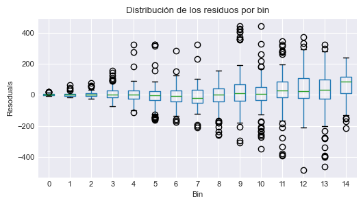

```python
# Distribución de los residuos por bin
# ==============================================================================
out_sample_residuals_by_bin_df = pd.DataFrame(
    dict([(k, pd.Series(v)) for k, v in forecaster.out_sample_residuals_by_bin_.items()])
)
fig, ax = plt.subplots(figsize=(6, 3))
out_sample_residuals_by_bin_df.boxplot(ax=ax)
ax.set_title("Distribución de los residuos por bin")
ax.set_xlabel("Bin")
ax.set_ylabel("Resoduals");
```

Los gráficos de caja ilustran cómo tanto la dispersión como la magnitud de los residuos varían con los valores predichos. Por ejemplo, en el bin 0, los residuos se mantienen dentro de un valor absoluto de 100, mientras que en los bins mayores a 5 superan con frecuencia este umbral.

Por último, los intervalos de predicción para los datos de test se estiman mediante el proceso de *backtesting*, con los residuos *out-sample* condicionados a los valores predichos.

```python
# Backtesting con intervalos en los datos de test usando residuos out-sample
# ==============================================================================
cv = TimeSeriesFold(
        steps              = 24,
        initial_train_size = len(data.loc[:end_validation]),
        refit              = False,
    )

metric, predictions = backtesting_forecaster(
                          forecaster              = forecaster,
                          y                       = data['users'],
                          exog                    = data[exog_features],
                          cv                      = cv,
                          metric                  = 'mean_absolute_error',
                          interval                = [10, 90],
                          n_boot                  = 250,
                          use_in_sample_residuals = False, # Usar residuos out-sample
                          use_binned_residuals    = True,  # Usar residuos por bin
                          n_jobs                  = 'auto',
                          verbose                 = False,
                          show_progress           = True
                      )
predictions.head(5)
```

|  | pred | lower_bound | upper_bound |
| --- | --- | --- | --- |
| 2012-11-16 00:00:00 | 75.957987 | 42.852151 | 153.661841 |
| 2012-11-16 01:00:00 | 22.895924 | 13.017612 | 90.814613 |
| 2012-11-16 02:00:00 | 11.105227 | 5.301970 | 43.867037 |
| 2012-11-16 03:00:00 | 7.465197 | 4.394094 | 23.024220 |
| 2012-11-16 04:00:00 | 6.216360 | 3.496328 | 19.235150 |

```python
# Gráfico intervalos
# ==============================================================================
plot_predicted_intervals(
    predictions     = predictions,
    y_true          = data_test,
    target_variable = "users",
    initial_x_zoom  = ['2012-12-01', '2012-12-25'],
    title           = "Valor real vs predicciones en el conjunto de test",
    xaxis_title     = "Date time",
    yaxis_title     = "users",
)

# Cobertura del intervalo en los datos de test
# ==============================================================================
coverage = empirical_coverage(
                y           = data.loc[end_validation:, 'users'],
                lower_bound = predictions["lower_bound"],
                upper_bound = predictions["upper_bound"]
            )
print(f"Cobertura del intervalo: {round(100*coverage, 2)} %")

# Area del intervalo
# ==============================================================================
area = (predictions["upper_bound"] - predictions["lower_bound"]).sum()
print(f"Area del intervalo: {round(area, 2)}")
```

[interactive chart not shown]

```
Cobertura del intervalo: 78.89 %
Area del intervalo: 209530.0
```

Cuando se utilizan residuos *out-sample* condicionados al valor predicho, el intervalo tiene una cobertura próxima al valor esperado (80%) a la vez que se reduce su amplitud. El modelo es capaz de distribuir mejor la incertidumbre en sus predicciones.

### Predicción: bootstraping, cuantiles y distribución

En las secciones anteriores se ha mostrado el uso del proceso de *backtesting* para estimar el intervalo de predicción a lo largo de un periodo de tiempo determinado. El objetivo es imitar el comportamiento del modelo en producción ejecutando predicciones a intervalos regulares, actualizando incrementalmente los datos de entrada.

También, es posible ejecutar una única predicción que estime *N strps* por delante sin pasar por todo el proceso de *backtesting*. En estos casos, skforecast ofrece cuatro métodos diferentes: `predict_bootstrapping`, `predict_interval`, `predict_quantile` y `predict_distribution`.

**Predict Bootstraping**

El método `predict_bootstrapping` realiza las iteraciones de *bootstrapping* para generar la muestra de posibles predicciones alternativas. Estos son los valores subyacentes utilizados para calcular los intervalos, cuantiles y distribuciones.

```python
# Entrenar forecaster
# ==============================================================================
forecaster.fit(
    y     = data.loc[:end_validation, 'users'],
    exog  = data.loc[:end_validation, exog_features]
)
```

```python
# Predecir 10 secuencias diferentes de 7 steps cada una usando bootstrapping
# ==============================================================================
boot_predictions = forecaster.predict_bootstrapping(
                       exog   = data_test[exog_features],
                       steps  = 7,
                       n_boot = 25
                   )
boot_predictions
```

|  | pred_boot_0 | pred_boot_1 | pred_boot_2 | pred_boot_3 | pred_boot_4 | pred_boot_5 | pred_boot_6 | pred_boot_7 | pred_boot_8 | pred_boot_9 | ... | pred_boot_15 | pred_boot_16 | pred_boot_17 | pred_boot_18 | pred_boot_19 | pred_boot_20 | pred_boot_21 | pred_boot_22 | pred_boot_23 | pred_boot_24 |
| --- | --- | --- | --- | --- | --- | --- | --- | --- | --- | --- | --- | --- | --- | --- | --- | --- | --- | --- | --- | --- | --- |
| 2012-11-16 00:00:00 | 75.072526 | 67.917014 | 90.497835 | 72.887786 | 69.451738 | 65.636227 | 67.752751 | 74.731177 | 87.611129 | 82.144507 | ... | 90.132866 | 136.833471 | 70.875736 | 66.419248 | 66.151284 | 74.751401 | 48.791706 | 68.656787 | 83.055140 | 68.128650 |
| 2012-11-16 01:00:00 | 33.217798 | 39.088561 | 53.430776 | 8.530052 | 31.098442 | 19.103678 | 25.434839 | 39.863960 | 53.959646 | -0.065547 | ... | 77.283496 | 103.139985 | 16.806962 | 24.998564 | 16.564876 | 8.105737 | 25.639537 | 47.999683 | 21.557125 | 21.669114 |
| 2012-11-16 02:00:00 | 30.117753 | 8.819270 | 21.098243 | 6.527203 | -2.097282 | 11.071403 | 8.829349 | 40.070996 | 9.417611 | -24.525254 | ... | 40.248554 | 47.861372 | 41.019650 | -5.893293 | 3.011746 | -13.445515 | 45.709909 | -11.076396 | 24.972022 | 20.706668 |
| 2012-11-16 03:00:00 | -2.370557 | 2.628568 | 8.867311 | -9.985030 | -1.431195 | 24.763869 | 2.948100 | -0.293142 | 8.415971 | 100.438948 | ... | 1.438511 | 4.828710 | 21.165506 | 7.745074 | -24.641198 | 4.783921 | 60.887626 | 17.057142 | -9.878423 | -22.821821 |
| 2012-11-16 04:00:00 | 33.421322 | -5.012262 | 18.803097 | 25.102996 | 32.054605 | 14.578793 | 52.905294 | -41.144396 | 16.813604 | 107.710606 | ... | -28.544466 | 1.939137 | -11.529134 | -11.649420 | 43.438586 | -0.654120 | 23.865921 | 7.612053 | 5.411233 | -1.574533 |
| 2012-11-16 05:00:00 | 81.259318 | 58.335735 | 23.256711 | 51.950788 | 51.408044 | 53.162599 | 62.032153 | 52.793819 | 42.212314 | 106.453046 | ... | 44.910476 | -2.765791 | 15.125106 | -17.912916 | 96.705426 | 30.322670 | 36.136752 | 34.202833 | 38.794849 | 35.524510 |
| 2012-11-16 06:00:00 | 195.059101 | 195.716369 | 125.295581 | 197.557367 | 171.269419 | 170.727804 | 175.102145 | 160.966413 | 157.567075 | 155.195939 | ... | 152.996113 | 123.790988 | 98.159621 | 100.287313 | 192.879471 | 125.427235 | 89.445302 | 129.648327 | 178.383805 | 136.410872 |

7 rows × 25 columns

Un gráfico de ridge es una forma útil de visualizar la incertidumbre asociada a las predicciones de un modelo de forecasting. Este gráfico muestra la distribución de desnidad para cada step utilizando las predicciones obtenidas por bootstrapping.

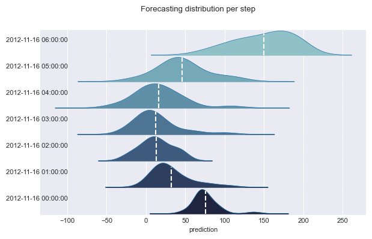

```python
# Ridge plot de las distribuciones de bootstrapping
# ==============================================================================
_ = plot_prediction_distribution(boot_predictions, figsize=(7, 4))
```

**Predict Interval**

En la mayoría de los casos, el usuario está interesado en un intervalo específico en lugar de toda la matriz de predicciones obtenida por *bootstrapping*. Para cubrir esta necesidad, skforecast proporciona el método `predict_interval`. Este método utiliza internamente `predict_bootstrapping` y estima los cuantiles superior e inferior para cada *step*, proporcionando así los intervalos de predicción deseados.

```python
# Predicción de intervalos para los siguiente 7 steps
# ==============================================================================
predictions = forecaster.predict_interval(
                  exog     = data_test[exog_features],
                  steps    = 7,
                  interval = [10, 90],
                  n_boot   = 150
              )
predictions
```

|  | pred | lower_bound | upper_bound |
| --- | --- | --- | --- |
| 2012-11-16 00:00:00 | 75.957987 | 55.871660 | 106.509594 |
| 2012-11-16 01:00:00 | 22.895924 | 2.862862 | 56.508504 |
| 2012-11-16 02:00:00 | 11.105227 | -13.861631 | 41.666618 |
| 2012-11-16 03:00:00 | 7.465197 | -14.729066 | 40.250606 |
| 2012-11-16 04:00:00 | 6.216360 | -16.066013 | 43.949188 |
| 2012-11-16 05:00:00 | 31.850292 | 10.522605 | 66.098993 |
| 2012-11-16 06:00:00 | 145.218401 | 96.256977 | 178.714044 |

**Predict Quantile**

Este método funciona de forma similar a `predict_interval`, con la característica añadida de que permite definir una lista específica de cuantiles. Es importante recordar que estos cuantiles deben estar dentro del intervalo [0, 1].

```python
# Predicción de cuantiles 5, 25, 75 and 95 para los siguientes 7 steps
# ==============================================================================
predictions = forecaster.predict_quantiles(
                  exog      = data_test[exog_features],
                  steps     = 7,
                  n_boot    = 150,
                  quantiles = [0.05, 0.25, 0.75, 0.95],
              )
predictions
```

|  | q_0.05 | q_0.25 | q_0.75 | q_0.95 |
| --- | --- | --- | --- | --- |
| 2012-11-16 00:00:00 | 48.288075 | 67.642808 | 90.037329 | 118.281854 |
| 2012-11-16 01:00:00 | -3.616814 | 16.409867 | 37.915283 | 64.523189 |
| 2012-11-16 02:00:00 | -20.478988 | -2.408681 | 22.836308 | 58.893143 |
| 2012-11-16 03:00:00 | -28.116105 | -2.513015 | 23.698522 | 51.932897 |
| 2012-11-16 04:00:00 | -27.432799 | -4.066136 | 22.940893 | 51.227532 |
| 2012-11-16 05:00:00 | -4.006249 | 21.569188 | 49.501503 | 76.194038 |
| 2012-11-16 06:00:00 | 83.860754 | 114.212367 | 156.516781 | 189.210857 |

**Predict Distribution**

Las estimaciones de intervalos mostradas en los apartados anteriores no hacen ninguna asunción sobre una distribución concreta. El método `predict_dist` de skforecast permite ajustar una distribución paramétrica a las simulaciones obtenidas con `predict_bootstrapping`. Esto es útil cuando hay razones para creer que los errores de predicción siguen una distribución particular, como la distribución normal o la distribución *t-student*. El método `predict_dist` permite al usuario especificar cualquier distribución continua del módulo [scipy.stats](https://docs.scipy.org/doc/scipy/reference/stats.html#continuous-distributions).

```python
# Predicción de  los parámetros de una distribución normal en cada uno de los siguentes 7 steps
# ==============================================================================
predictions = forecaster.predict_dist(
                  exog         = data_test[exog_features],
                  steps        = 7,
                  n_boot       = 150,
                  distribution = norm
              )
predictions
```

|  | loc | scale |
| --- | --- | --- |
| 2012-11-16 00:00:00 | 79.436270 | 21.590643 |
| 2012-11-16 01:00:00 | 27.275039 | 26.421942 |
| 2012-11-16 02:00:00 | 12.963605 | 25.253451 |
| 2012-11-16 03:00:00 | 9.804574 | 25.410589 |
| 2012-11-16 04:00:00 | 10.522987 | 25.929452 |
| 2012-11-16 05:00:00 | 34.254031 | 25.946783 |
| 2012-11-16 06:00:00 | 135.548288 | 36.410460 |

## Intervalos de predicción utilizando modelos de regresión cuantílica

A diferencia de los modelos de regresión más comunes, que pretende estimar la media de la variable respuesta dados ciertos valores de las variables predictoras, la regresión cuantílica tiene como objetivo estimar los cuantiles condicionales de la variable respuesta. Para una función de distribución continua, el cuantil $\alpha$ $Q_{\alpha}(x)$ se define como el valor tal que la probabilidad de que $Y$ sea menor que $Q_{\alpha}(x)$ es, para un determinado $X=x$, igual a $\alpha$. Por ejemplo, el 36% de los valores de la población son inferiores al cuantil $Q=0,36$. El cuantil más conocido es el cuantil 50%, más comúnmente conocido como mediana.

Al combinar las predicciones de dos modelos de regresión cuantílica, es posible construir un intervalo donde, cada modelo, estima uno de los límites del intervalo. Por ejemplo, los modelos obtenidos para $Q = 0.1$ y $Q = 0.9$ generan un intervalo de predicción del 80% (90% - 10% = 80%).

Son varios los algoritmos de *machine learning* capaces de modelar cuantiles. Algunos de ellos son:

- [LightGBM](https://lightgbm.readthedocs.io/en/latest/index.html)
- [XGBoost](https://xgboost.readthedocs.io/en/stable/python/index.html)
- [CatBoost](https://catboost.ai/en/docs/concepts/python-reference_catboostregressor)
- [Scikit-learn HistGradientBoostingRegressor](https://scikit-learn.org/stable/modules/generated/sklearn.ensemble.HistGradientBoostingRegressor.html)
- [Scikit-learn QuantileRegressor](https://scikit-learn.org/stable/modules/generated/sklearn.linear_model.QuantileRegressor.html#sklearn.linear_model.QuantileRegressor)
- [skranger quantile RandomForest](https://skranger.readthedocs.io/en/stable/index.html)

Así como el error cuadrático se utiliza como función de coste para entrenar modelos que predicen el valor medio, se necesita una función de coste específica para entrenar modelos que predicen cuantiles. La función utilizada con más frecuencia para la regresión de cuantiles se conoce como [*pinball*](https://en.wikipedia.org/wiki/Quantile_regression):

$$\text{pinball}(y, \hat{y}) = \frac{1}{n_{\text{muestras}}} \sum_{i=0}^{n_{\text{muestras}}- 1} \alpha \max(y_i - \hat{y}_i, 0) + (1 - \alpha) \max(\hat{y}_i - y_i, 0)$$

donde $\alpha$ es el cuantil objetivo, $y$ el valor real e $\hat{y}$ la predicción del cuantil.

Se puede observar que el coste difiere según el cuantil evaluado. Cuanto mayor sea el cuantil, más se penalizan las subestimaciones y menos las sobreestimaciones. Al igual que con MSE y MAE, el objetivo es minimizar sus valores (a menor coste, mejor).

Dos desventajas de la regresión por cuantiles en comparación con el método de *bootstrapping* son: que cada cuantil necesita su regresor, y que la regresión por cuantiles no está disponible para todos los tipos de modelos de regresión. Sin embargo, una vez entrenados los modelos, la inferencia es mucho más rápida ya que no se necesita un proceso iterativo.

Este tipo de intervalos de predicción se pueden estimar fácilmente utilizando [ForecasterDirect](https://skforecast.org/latest/api/ForecasterDirect.html).

**⚠ Warning**

Los forecaters de tipo `ForecasterDirect` son más lentos que los `ForecasterRecursiveRecursive` porque requieren el entrenamiento de un modelo por *step*. Para limitar el tiempo necesario para ejecutar los siguientes ejemplos, los datos se agregan a frecuencia diaria y sólo se predicen 7 los siguientes 7 dias (una semana).

### Datos

```python
# Descarga de datos
# ==============================================================================
data = fetch_dataset(name='bike_sharing_extended_features', verbose=False)
```

```python
# Agragar datos a frecuencia horaria
# ==============================================================================
data = (
    data
    .resample(rule="D", closed="left", label="right")
    .agg({"users": "sum"})
)
```

```python
# Particion train-validation-test
# ==============================================================================
end_train = '2012-05-31 23:59:00'
end_validation = '2012-09-15 23:59:00'
data_train = data.loc[: end_train, :]
data_val   = data.loc[end_train:end_validation, :]
data_test  = data.loc[end_validation:, :]
print(f"Fechas train      : {data_train.index.min()} --- {data_train.index.max()}  (n={len(data_train)})")
print(f"Fechas validacion : {data_val.index.min()} --- {data_val.index.max()}  (n={len(data_val)})")
print(f"Fechas test       : {data_test.index.min()} --- {data_test.index.max()}  (n={len(data_test)})")
```

```
Fechas train      : 2011-01-09 00:00:00 --- 2012-05-31 00:00:00  (n=509)
Fechas validacion : 2012-06-01 00:00:00 --- 2012-09-15 00:00:00  (n=107)
Fechas test       : 2012-09-16 00:00:00 --- 2012-12-31 00:00:00  (n=107)
```

## Modelos de regresión por cuantiles

Se estima un intervalo de predicción del 80% para los siguientes 7 días. En este ejemplo, se entrena un modelo de *gradient boosting LightGBM*, sin embargo, el lector puede utilizar cualquier otro modelo simplemente reemplazando la definición del regresor.

```python
# Crear forecasters: uno para cada límite del intervalo
# ==============================================================================
# Los forecasters obtenidos para alpha=0.1 y alpha=0.9 producen un intervalo de
# confianza del 80% (90% - 10% = 80%).

# Forecaster para cuantil 10%
forecaster_q10 = ForecasterDirect(
                     regressor = LGBMRegressor(
                                     objective    = 'quantile',
                                     metric       = 'quantile',
                                     alpha        = 0.1,
                                     random_state = 15926,
                                     verbose      = -1

                                 ),
                     lags  = 7,
                     steps = 7
                 )

# Forecaster para cuantil 90%
forecaster_q90 = ForecasterDirect(
                     regressor = LGBMRegressor(
                                     objective    = 'quantile',
                                     metric       = 'quantile',
                                     alpha        = 0.9,
                                     random_state = 15926,
                                     verbose      = -1

                                 ),
                     lags  = 7,
                     steps = 7
                 )
```

Al validar un modelo de regresión por cuantiles, se debe proporcionar una métrica personalizada según el cuantil que se esté estimando.

```python
# Función de coste para cada cuantil (pinball_loss)
# ==============================================================================
def mean_pinball_loss_q10(y_true, y_pred):
    """
    Pinball loss for quantile 10.
    """
    return mean_pinball_loss(y_true, y_pred, alpha=0.1)


def mean_pinball_loss_q90(y_true, y_pred):
    """
    Pinball loss for quantile 90.
    """
    return mean_pinball_loss(y_true, y_pred, alpha=0.9)
```

```python
# Grid search para los hyper-parámetros y lags de cada quantile-forecaster
# ==============================================================================
def search_space(trial):
    search_space  = {
        'n_estimators'  : trial.suggest_int('n_estimators', 100, 500, step=50),
        'max_depth'     : trial.suggest_int('max_depth', 3, 10, step=1),
        'learning_rate' : trial.suggest_float('learning_rate', 0.01, 0.1)
    }

    return search_space

cv = TimeSeriesFold(
        steps              = 7,
        initial_train_size = len(data[:end_train]),
        refit              = False,
    )

results_grid_q10 = bayesian_search_forecaster(
                       forecaster     = forecaster_q10,
                       y              = data.loc[:end_validation, 'users'],
                       cv             = cv,
                       metric         = mean_pinball_loss_q10,
                       search_space   = search_space,
                       n_trials       = 10,
                       random_state   = 123,
                       return_best    = True,
                       n_jobs         = 'auto',
                       verbose        = False,
                       show_progress  = True
                   )

results_grid_q90 = bayesian_search_forecaster(
                       forecaster    = forecaster_q90,
                       y             = data.loc[:end_validation, 'users'],
                       cv            = cv,
                       metric        = mean_pinball_loss_q90,
                       search_space  = search_space,
                       n_trials      = 10,
                       random_state  = 123,
                       return_best   = True,
                       n_jobs        = 'auto',
                       verbose       = False,
                       show_progress = True
                   )
```

```
`Forecaster` refitted using the best-found lags and parameters, and the whole data set:
  Lags: [1 2 3 4 5 6 7]
  Parameters: {'n_estimators': 250, 'max_depth': 3, 'learning_rate': 0.04582398297973883}
  Backtesting metric: 222.8916557556898
```

```
`Forecaster` refitted using the best-found lags and parameters, and the whole data set:
  Lags: [1 2 3 4 5 6 7]
  Parameters: {'n_estimators': 400, 'max_depth': 4, 'learning_rate': 0.02579065805327433}
  Backtesting metric: 164.5817884709446
```

Una vez que se han encontrado los mejores hiperparámetros para cada forecaster, se aplica un proceso de [*backtesting*](https://skforecast.org/latest/user_guides/backtesting.html) utilizando los datos de test.

```python
# Backtesting con datos de test
# ==============================================================================
cv = TimeSeriesFold(
        steps              = 7,
        initial_train_size = len(data.loc[:end_validation]),
        refit              = False,
    )
metric_q10, predictions_q10 = backtesting_forecaster(
                                  forecaster    = forecaster_q10,
                                  y             = data['users'],
                                  cv            = cv,
                                  metric        = mean_pinball_loss_q10,
                                  n_jobs        = 'auto',
                                  verbose       = False,
                                  show_progress = True
                              )

metric_q90, predictions_q90 = backtesting_forecaster(
                                  forecaster    = forecaster_q90,
                                  y             = data['users'],
                                  cv            = cv,
                                  metric        = mean_pinball_loss_q90,
                                  n_jobs        = 'auto',
                                  verbose       = False,
                                  show_progress = True
                              )
```

```python
# Gráfico
# ==============================================================================
fig = go.Figure([
    go.Scatter(name='Real value', x=data_test.index, y=data_test['users'], mode='lines'),
    go.Scatter(
        name='Upper Bound', x=predictions_q90.index, y=predictions_q90['pred'],
        mode='lines', marker=dict(color="#444"), line=dict(width=0), showlegend=False
    ),
    go.Scatter(
        name='Lower Bound', x=predictions_q10.index, y=predictions_q10['pred'],
        marker=dict(color="#444"), line=dict(width=0), mode='lines',
        fillcolor='rgba(68, 68, 68, 0.3)', fill='tonexty', showlegend=False
    )
])
fig.update_layout(
    title="Valores reales vs predicciones en los datos de test",
    xaxis_title="Date time",
    yaxis_title="users",
    width=750,
    height=350,
    margin=dict(l=20, r=20, t=35, b=20),
    hovermode="x",
    legend=dict(orientation="h", yanchor="top", y=1.1, xanchor="left", x=0.001)
)
fig.show()
```

[interactive chart not shown]

```python
# Cobertura del intervalo en los datos de test
# ==============================================================================
coverage = empirical_coverage(
                y           = data.loc[end_validation:, 'users'],
                lower_bound = predictions_q10["pred"],
                upper_bound = predictions_q90["pred"]
            )
print(f"Cobertura del intervalo: {round(100 * coverage, 2)} %")

# Area del intervalo
# ==============================================================================
area = (predictions_q90["pred"] - predictions_q10["pred"]).sum()
print(f"Area del intervalo: {round(area, 2)}")
```

```
Cobertura del intervalo: 49.53 %
Area del intervalo: 207151.73
```

En este caso de uso, la estrategia de previsión cuantílica no logra una cobertura empírica cercana a la esperada (80%).

## Información de sesión

```python
import session_info
session_info.show(html=False)
```

```
-----
lightgbm            4.4.0
matplotlib          3.9.0
numpy               2.0.2
optuna              4.0.0
pandas              2.2.3
plotly              5.23.0
scipy               1.14.1
session_info        1.0.0
skforecast          0.14.0
sklearn             1.5.2
statsmodels         0.14.2
-----
IPython             8.25.0
jupyter_client      8.6.2
jupyter_core        5.7.2
notebook            6.4.12
-----
Python 3.12.4 | packaged by Anaconda, Inc. | (main, Jun 18 2024, 15:03:56) [MSC v.1929 64 bit (AMD64)]
Windows-11-10.0.26100-SP0
-----
Session information updated at 2024-11-04 11:52
```

## Bibliografía

Hyndman, R.J., & Athanasopoulos, G. (2021) Forecasting: principles and practice, 3rd edition, OTexts: Melbourne, Australia. [book](https://otexts.com/fpp3/)

Time Series Analysis and Forecasting with ADAM Ivan Svetunkov [book](https://openforecast.org/adam/)

Python for Finance: Mastering Data-Driven Finance [book](https://www.amazon.es/gp/product/1492024333/ref=as_li_qf_asin_il_tl?ie=UTF8&tag=cienciadedato-21&creative=24630&linkCode=as2&creativeASIN=1492024333&linkId=70c3175ad015970cd1c2328b7a40a055)

Forecasting: theory and practice [PDF](https://arxiv.org/pdf/2012.03854.pdf)

## Instrucciones para citar

**¿Cómo citar este documento?**

Si utilizas este documento o alguna parte de él, te agradecemos que lo cites. ¡Muchas gracias!

Forecasting probabilistico con machine learning por Joaquín Amat Rodrigo y Javier Escobar Ortiz, , disponible bajo una licencia Attribution-NonCommercial-ShareAlike 4.0 International (CC BY-NC-SA 4.0 DEED) en https://www.cienciadedatos.net/documentos/py42-foreasting-probabilistico.html

**¿Cómo citar skforecast?**

Si utilizas skforecast en tu investigación o publicación, te lo agradeceríamos mucho que lo cites. ¡Muchas gracias!

Zenodo:

Amat Rodrigo, Joaquin, & Escobar Ortiz, Javier. (2024). skforecast (v0.14.0). Zenodo. https://doi.org/10.5281/zenodo.8382788

APA:

Amat Rodrigo, J., & Escobar Ortiz, J. (2024). skforecast (Version 0.14.0) [Computer software]. https://doi.org/10.5281/zenodo.8382788

BibTeX:

@software{skforecast, author = {Amat Rodrigo, Joaquin and Escobar Ortiz, Javier}, title = {skforecast}, version = {0.14.0}, month = {11}, year = {2024}, license = {BSD-3-Clause}, url = {https://skforecast.org/}, doi = {10.5281/zenodo.8382788} }

Este documento creado por Joaquín Amat Rodrigo y Javier Escobar Ortiz tiene licencia [Attribution-NonCommercial-ShareAlike 4.0 International](https://creativecommons.org/licenses/by-nc-sa/4.0/).